# Exercise Activity Prediction Report

P.Y.Fong

01/03/2021

## 1.0 Executive Summary

The objective of this project was to build a model to predict the manner which participants performed a weight lifting exercise using data from from the Human Activity Recognition website http://groupware.les.inf.puc-rio.br/har

Data was collected from accelerometers on the belt, forearm, arm, and dumbbell of 6 participants, in the weight lifting exercise.

The model developed in this report was based on the Random Forest Model, cross validated 5 fold and when tested with a validation data set, produced an accuracy of 99.76%, 99.7% kappa.  
Out of Sample Error was estimated at 0.24%.

The results when used to predict on the test data set was:  
B A B A A E D B A A B C B A E E A B B B

## 2.0 Data Preprocessing.

### 2.1 Libraries.

```r
library(lattice)
library(ggplot2)
library(caret)
library(data.table)
library(dplyr)
library(randomForest)
```

### 2.2 Data Download.

```r
trainUrl <-"https://d396qusza40orc.cloudfront.net/predmachlearn/pml-training.csv"
testUrl <- "https://d396qusza40orc.cloudfront.net/predmachlearn/pml-testing.csv"
trainFile <- "./data/pml-training.csv"
testFile <- "./data/pml-testing.csv"

if (!file.exists("./data")) {dir.create("./data")}
if (!file.exists(trainFile)) {download.file(trainUrl, destfile=trainFile, method="curl")}
if (!file.exists(testFile)) {download.file(testUrl, destfile=testFile, method="curl")}

train <- fread("./data/pml-training.csv")
test <- fread("./data/pml-testing.csv")
```

### 2.3 Data Exploration.

```r
str(train,list.len = 20) # train data structure. (Truncated in report)
```

```
## Classes 'data.table' and 'data.frame':   19622 obs. of  160 variables:
##  $ V1                      : int  1 2 3 4 5 6 7 8 9 10 ...
##  $ user_name               : chr  "carlitos" "carlitos" "carlitos" "carlitos" ...
##  $ raw_timestamp_part_1    : int  1323084231 1323084231 1323084231 1323084232 1323084232 1323084232 1323084232 1323084232 1323084232 1323084232 ...
##  $ raw_timestamp_part_2    : int  788290 808298 820366 120339 196328 304277 368296 440390 484323 484434 ...
##  $ cvtd_timestamp          : chr  "05/12/2011 11:23" "05/12/2011 11:23" "05/12/2011 11:23" "05/12/2011 11:23" ...
##  $ new_window              : chr  "no" "no" "no" "no" ...
##  $ num_window              : int  11 11 11 12 12 12 12 12 12 12 ...
##  $ roll_belt               : num  1.41 1.41 1.42 1.48 1.48 1.45 1.42 1.42 1.43 1.45 ...
##  $ pitch_belt              : num  8.07 8.07 8.07 8.05 8.07 8.06 8.09 8.13 8.16 8.17 ...
##  $ yaw_belt                : num  -94.4 -94.4 -94.4 -94.4 -94.4 -94.4 -94.4 -94.4 -94.4 -94.4 ...
##  $ total_accel_belt        : int  3 3 3 3 3 3 3 3 3 3 ...
##  $ kurtosis_roll_belt      : num  NA NA NA NA NA NA NA NA NA NA ...
##  $ kurtosis_picth_belt     : num  NA NA NA NA NA NA NA NA NA NA ...
##  $ kurtosis_yaw_belt       : num  NA NA NA NA NA NA NA NA NA NA ...
##  $ skewness_roll_belt      : num  NA NA NA NA NA NA NA NA NA NA ...
##  $ skewness_roll_belt.1    : num  NA NA NA NA NA NA NA NA NA NA ...
##  $ skewness_yaw_belt       : num  NA NA NA NA NA NA NA NA NA NA ...
##  $ max_roll_belt           : num  NA NA NA NA NA NA NA NA NA NA ...
##  $ max_picth_belt          : int  NA NA NA NA NA NA NA NA NA NA ...
##  $ max_yaw_belt            : num  NA NA NA NA NA NA NA NA NA NA ...
##   [list output truncated]
##  - attr(*, ".internal.selfref")=<externalptr>
```

```r
trainlowvar <- length(nearZeroVar(train))
testlowvar <- length(nearZeroVar(test))
```

### 2.4 Data Cleaning.

1. Eliminated identifiers, low variance & all NA values variables from test.
2. Eliminated all unnecessary variables from train using cleaned test variables as reference.

```r
test <- test %>% select (-(1:6)) %>%
  select (- nearZeroVar(test)) %>%
  select_if(~sum(!is.na(.)) > 0)

train <- train %>% select (names(test)[1:24],classe)
```

The cleaned data sets now contained;

- test - 20 observations of 25 variables. “problem_id” is unique.
- train - 19622 observations of 25 variables. “classe” is unique.

### 2.5 Partitioning a Validation Set.

Split train into trainf (70%) and valid (30%). The valid data set was to be used to conduct cross validation.

```r
set.seed(2468) # reproducibility
part <- createDataPartition(train$classe, p=0.70, list=F)
trainf <- train[part,]
valid <- train[-part,]
```

The training data sets now contained;

- trainf - 13737 observations of 25 variables.
- valid - 5885 observations of 25 variables.

*Refer Visualization 4.1* - It was noted that many of the variables were either positively or negatively correlated with each other.

## 3.0 Prediction Model.

The Random Forest algorithm was selected because it automatically selects important variables and is robust to correlated variables & outliers.  
5 fold Cross validation was applied.

```r
rfcont <- trainControl(method="cv", 5)
rfmodel <- train(classe ~ ., data=trainf, method="rf", trControl=rfcont, ntree=250)
rfmodel
```

```
## Random Forest
##
## 13737 samples
##    24 predictor
##     5 classes: 'A', 'B', 'C', 'D', 'E'
##
## No pre-processing
## Resampling: Cross-Validated (5 fold)
## Summary of sample sizes: 10989, 10991, 10990, 10988, 10990
## Resampling results across tuning parameters:
##
##   mtry  Accuracy   Kappa
##    2    0.9946860  0.9932787
##   13    0.9978161  0.9972376
##   24    0.9955596  0.9943835
##
## Accuracy was used to select the optimal model using the largest value.
## The final value used for the model was mtry = 13.
```

*Refer Visualization 4.2*

### 3.1 Prediction Against Validation Set.

```r
rfpred <- predict(rfmodel, valid)
cf <- confusionMatrix(as.factor(valid$classe), rfpred)
cf
```

```
## Confusion Matrix and Statistics
##
##           Reference
## Prediction    A    B    C    D    E
##          A 1674    0    0    0    0
##          B    3 1128    8    0    0
##          C    0    1 1025    0    0
##          D    0    0    1  963    0
##          E    0    0    0    1 1081
##
## Overall Statistics
##
##                Accuracy : 0.9976
##                  95% CI : (0.996, 0.9987)
##     No Information Rate : 0.285
##     P-Value [Acc > NIR] : < 2.2e-16
##
##                   Kappa : 0.997
##
##  Mcnemar's Test P-Value : NA
##
## Statistics by Class:
##
##                      Class: A Class: B Class: C Class: D Class: E
## Sensitivity            0.9982   0.9991   0.9913   0.9990   1.0000
## Specificity            1.0000   0.9977   0.9998   0.9998   0.9998
## Pos Pred Value         1.0000   0.9903   0.9990   0.9990   0.9991
## Neg Pred Value         0.9993   0.9998   0.9981   0.9998   1.0000
## Prevalence             0.2850   0.1918   0.1757   0.1638   0.1837
## Detection Rate         0.2845   0.1917   0.1742   0.1636   0.1837
## Detection Prevalence   0.2845   0.1935   0.1743   0.1638   0.1839
## Balanced Accuracy      0.9991   0.9984   0.9955   0.9994   0.9999
```

### 3.2 Accuracy and Out of Sample Error.

```r
accuracy <- cf$overall['Accuracy']
kappa <- cf$overall['Kappa']
oose <- 1 - accuracy
```

The RF model Accuracy was 99.76%  
Kappa was 99.7%.  
and the Out of Sample Error was 0.24%.

These values were found to be acceptable.

### 3.3 Predicting on Test Data Set.

```r
testpred <- predict(rfmodel, test)
testpred
```

```
##  [1] B A B A A E D B A A B C B A E E A B B B
## Levels: A B C D E
```

## 4.0 Visualizations.

### 4.1 Correlation Matrix.

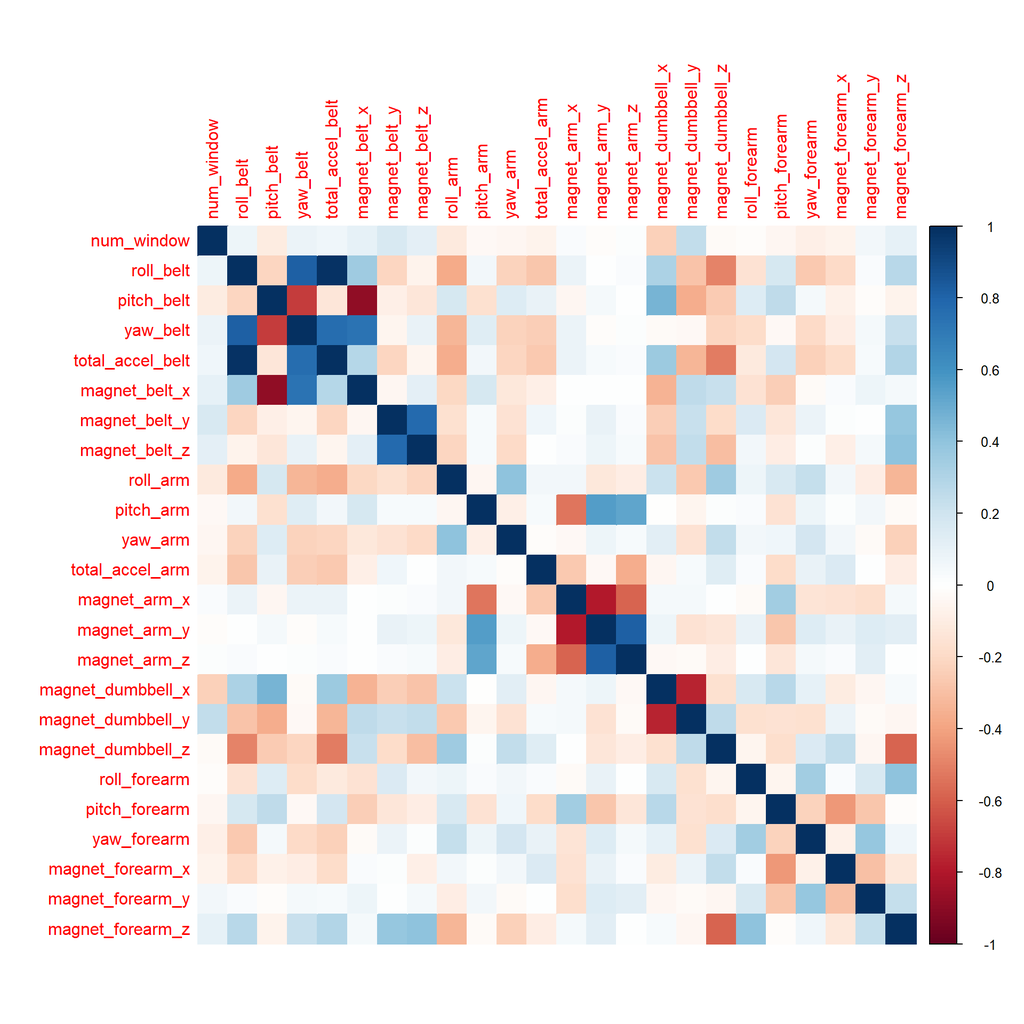

```r
Matrixplot <- cor(train[, -"classe"])
corrplot(Matrixplot, method="color")
```

### 4.2 Tree Diagram.

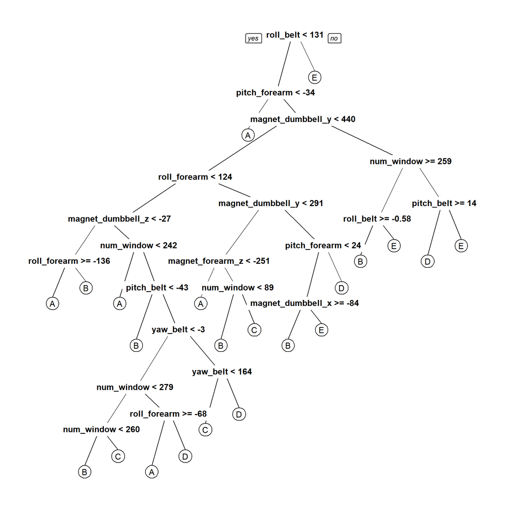

```r
treemodel <- rpart(classe ~ ., data=train, method="class")
prp(treemodel)
```